# Statistical analysis of OCT data

Investigation of Structural Alterations in Inherited Retinal Diseases: A Quantitative SD-OCT-Analysis of Retinal Layer Thicknesses in Light of Underlying Genetic Mutations

Julien Delarocque

2023-01-31

[figure not shown]

# 1 Summary

This script reproduces the essential parts of the analysis presented in (Gersch et al. 2022) on a mock data set. Consequently, **the results are purely random!**

While the general rationale of the analysis was validated by peer-review, please note that the script itself was not reviewed. The script is provided under an [Apache license 2.0](https://www.apache.org/licenses/LICENSE-2.0.txt).

Please cite as (Delarocque 2023).

# 2 Dataset

The here provided data set was randomly generated based on the case numbers, means and standard deviations by disease entity, layer and segment in the original paper. For details about layer and segment definition please see (Gersch et al. 2022).

# 3 Interocular symmetry

Multivariate assessment of interocular symmetry by PCA and euclidean distance.

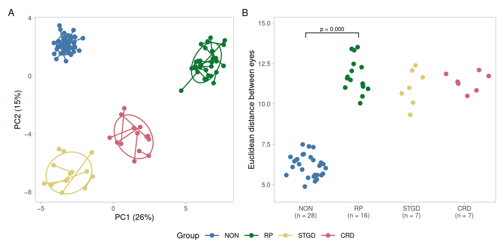

(A) Principal component analysis of the OCT data. Eye pairs a connected by a line. (B) Euclidean distance between eye pairs by group.

The ANOVA suggests that:

- The main effect of disease is statistically significant and large (F(3, 54) = 194.92, p < .001; Eta2 = 0.92, 95% CI [0.88, 1.00])

Effect sizes were labelled following Field’s (2013) recommendations.

Dunnett pairwise comparisons among groups. The different group sizes should be accounted for in the interpretation.

| contrast | estimate | SE | df | t.ratio | p.value |
| --- | --- | --- | --- | --- | --- |
| RP - NON | 5.559057 | 0.2627113 | 54 | 21.16033 | 0 |
| STGD - NON | 4.847748 | 0.3542398 | 54 | 13.68493 | 0 |
| CRD - NON | 5.203080 | 0.3542398 | 54 | 14.68802 | 0 |

# 4 Alterations of the retinal structure in IRDs

## 4.1 Retinitis pigmentosa

|  | NON (N=16) | RP (N=16) |
| --- | --- | --- |
| age |  |  |
| Mean (SD) | 36.7 (15.2) | 36.8 (16.0) |
| Median [Min, Max] | 38.3 [8.86, 56.8] | 38.9 [7.40, 62.7] |
| sex |  |  |
| f | 8 (50.0%) | 8 (50.0%) |
| m | 8 (50.0%) | 8 (50.0%) |

Top 20 most significantly different segment thicknesses.

| layer | segment | Coefficient | SE | CI_low | CI_high | t | df_error | p | adj.p |
| --- | --- | --- | --- | --- | --- | --- | --- | --- | --- |
| ORL | I2 | -83.937 | 2.287 | -88.509 | -79.366 | -36.706 | 62 | 0 | 0 |
| ONL | I2 | -38.875 | 1.430 | -41.733 | -36.017 | -27.189 | 62 | 0 | 0 |
| ORL | T2 | -84.469 | 3.176 | -90.818 | -78.119 | -26.592 | 62 | 0 | 0 |
| ONL | T2 | -43.437 | 1.666 | -46.768 | -40.107 | -26.072 | 62 | 0 | 0 |
| ORL | N2 | -78.750 | 3.030 | -84.808 | -72.692 | -25.987 | 62 | 0 | 0 |
| ORL | S2 | -81.125 | 3.147 | -87.416 | -74.834 | -25.779 | 62 | 0 | 0 |
| PR1_2 | S2 | -42.906 | 1.665 | -46.234 | -39.578 | -25.772 | 62 | 0 | 0 |
| PR1_2 | I2 | -42.250 | 1.887 | -46.023 | -38.477 | -22.386 | 62 | 0 | 0 |
| ONL | S2 | -42.563 | 2.017 | -46.595 | -38.530 | -21.099 | 62 | 0 | 0 |
| ONL | N2 | -41.094 | 1.967 | -45.026 | -37.162 | -20.892 | 62 | 0 | 0 |
| PR1_2 | N2 | -38.781 | 2.029 | -42.837 | -34.725 | -19.114 | 62 | 0 | 0 |
| ONL | T1 | -46.219 | 2.619 | -51.454 | -40.984 | -17.648 | 62 | 0 | 0 |
| ORL | I1 | -77.531 | 4.720 | -86.966 | -68.097 | -16.427 | 62 | 0 | 0 |
| ONL | I1 | -43.125 | 2.704 | -48.530 | -37.720 | -15.951 | 62 | 0 | 0 |
| ORL | T1 | -76.281 | 5.228 | -86.731 | -65.831 | -14.592 | 62 | 0 | 0 |
| PR1_2 | T2 | -37.469 | 2.640 | -42.747 | -32.191 | -14.191 | 62 | 0 | 0 |
| ORL | S1 | -69.969 | 5.062 | -80.087 | -59.851 | -13.823 | 62 | 0 | 0 |
| RNFL | S2 | 25.625 | 2.140 | 21.348 | 29.902 | 11.975 | 62 | 0 | 0 |
| Retina | T2 | -64.062 | 5.543 | -75.143 | -52.982 | -11.557 | 62 | 0 | 0 |
| RNFL | T2 | 11.000 | 0.973 | 9.055 | 12.945 | 11.304 | 62 | 0 | 0 |

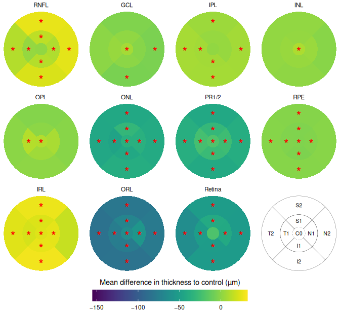

**Mean difference in thickness between RP and controls by layer and segment.** Significant differences are denoted with a star (*).

## 4.2 Cone-rods dystrophie

|  | NON (N=7) | CRD (N=7) |
| --- | --- | --- |
| age |  |  |
| Mean (SD) | 34.9 (11.9) | 33.2 (10.3) |
| Median [Min, Max] | 34.7 [17.1, 54.2] | 34.1 [18.2, 49.0] |
| sex |  |  |
| f | 3 (42.9%) | 3 (42.9%) |
| m | 4 (57.1%) | 4 (57.1%) |

Top 20 most significantly different segment thicknesses.

| layer | segment | Coefficient | SE | CI_low | CI_high | t | df_error | p | adj.p |
| --- | --- | --- | --- | --- | --- | --- | --- | --- | --- |
| Retina | N1 | -116.643 | 7.110 | -131.257 | -102.028 | -16.406 | 26 | 0 | 0 |
| Retina | T1 | -125.786 | 9.128 | -144.550 | -107.022 | -13.779 | 26 | 0 | 0 |
| ONL | C0 | -66.500 | 5.310 | -77.414 | -55.586 | -12.525 | 26 | 0 | 0 |
| IPL | I1 | -7.000 | 0.581 | -8.194 | -5.806 | -12.053 | 26 | 0 | 0 |
| ONL | T2 | -30.286 | 2.603 | -35.635 | -24.936 | -11.637 | 26 | 0 | 0 |
| ORL | I1 | -90.714 | 8.039 | -107.239 | -74.190 | -11.284 | 26 | 0 | 0 |
| ONL | T1 | -42.714 | 3.923 | -50.779 | -34.650 | -10.887 | 26 | 0 | 0 |
| ORL | N1 | -67.714 | 6.993 | -82.089 | -53.340 | -9.683 | 26 | 0 | 0 |
| INL | T1 | -8.429 | 0.979 | -10.440 | -6.417 | -8.612 | 26 | 0 | 0 |
| Retina | N2 | -74.429 | 9.178 | -93.293 | -55.564 | -8.110 | 26 | 0 | 0 |
| ONL | N1 | -39.357 | 5.047 | -49.731 | -28.983 | -7.798 | 26 | 0 | 0 |
| INL | N1 | -9.071 | 1.186 | -11.510 | -6.633 | -7.647 | 26 | 0 | 0 |
| RPE | N1 | -4.929 | 0.648 | -6.260 | -3.597 | -7.610 | 26 | 0 | 0 |
| ORL | S2 | -59.286 | 7.867 | -75.457 | -43.115 | -7.536 | 26 | 0 | 0 |
| Retina | I1 | -88.286 | 11.826 | -112.595 | -63.976 | -7.465 | 26 | 0 | 0 |
| ONL | I1 | -41.786 | 5.607 | -53.311 | -30.261 | -7.453 | 26 | 0 | 0 |
| Retina | T2 | -67.571 | 9.529 | -87.158 | -47.985 | -7.091 | 26 | 0 | 0 |
| IPL | T1 | -5.929 | 0.858 | -7.693 | -4.165 | -6.909 | 26 | 0 | 0 |
| GCL | I2 | -8.214 | 1.226 | -10.735 | -5.694 | -6.699 | 26 | 0 | 0 |
| ORL | C0 | -91.429 | 13.711 | -119.612 | -63.245 | -6.668 | 26 | 0 | 0 |

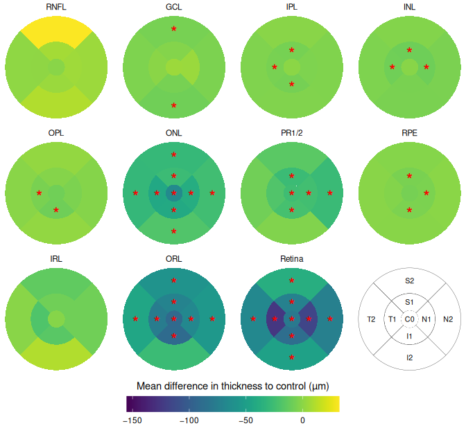

**Mean difference in thickness between CRD and controls by layer and segment.** Significant differences are denoted with a star (*).

## 4.3 Morbus Stargard

|  | NON (N=7) | STGD (N=7) |
| --- | --- | --- |
| age |  |  |
| Mean (SD) | 40.1 (17.8) | 39.6 (16.8) |
| Median [Min, Max] | 35.7 [17.1, 70.9] | 34.3 [14.1, 68.0] |
| sex |  |  |
| f | 5 (71.4%) | 5 (71.4%) |
| m | 2 (28.6%) | 2 (28.6%) |

Top 20 most significantly different segment thicknesses.

| layer | segment | Coefficient | SE | CI_low | CI_high | t | df_error | p | adj.p |
| --- | --- | --- | --- | --- | --- | --- | --- | --- | --- |
| ONL | C0 | -71.714 | 3.367 | -78.636 | -64.793 | -21.298 | 26 | 0 | 0 |
| ORL | C0 | -116.214 | 7.405 | -131.435 | -100.994 | -15.694 | 26 | 0 | 0 |
| Retina | C0 | -154.071 | 10.365 | -175.376 | -132.767 | -14.865 | 26 | 0 | 0 |
| PR1_2 | C0 | -42.571 | 3.669 | -50.113 | -35.030 | -11.603 | 26 | 0 | 0 |
| ONL | N1 | -42.500 | 3.814 | -50.340 | -34.660 | -11.143 | 26 | 0 | 0 |
| ONL | T1 | -53.143 | 5.037 | -63.497 | -42.789 | -10.550 | 26 | 0 | 0 |
| ORL | I1 | -48.714 | 5.217 | -59.438 | -37.991 | -9.338 | 26 | 0 | 0 |
| ORL | T1 | -61.071 | 6.660 | -74.761 | -47.382 | -9.170 | 26 | 0 | 0 |
| PR1_2 | T1 | -18.714 | 2.063 | -22.956 | -14.473 | -9.070 | 26 | 0 | 0 |
| ORL | N1 | -62.000 | 6.937 | -76.260 | -47.740 | -8.937 | 26 | 0 | 0 |
| ONL | I1 | -45.643 | 5.202 | -56.335 | -34.951 | -8.775 | 26 | 0 | 0 |
| Retina | T1 | -125.786 | 14.350 | -155.283 | -96.289 | -8.766 | 26 | 0 | 0 |
| IPL | I1 | -13.286 | 1.524 | -16.418 | -10.153 | -8.718 | 26 | 0 | 0 |
| Retina | N1 | -121.857 | 14.071 | -150.780 | -92.934 | -8.660 | 26 | 0 | 0 |
| RPE | C0 | -4.857 | 0.601 | -6.092 | -3.622 | -8.082 | 26 | 0 | 0 |
| IRL | T1 | -55.857 | 6.932 | -70.105 | -41.609 | -8.058 | 26 | 0 | 0 |
| ONL | I2 | -22.571 | 2.839 | -28.406 | -16.736 | -7.951 | 26 | 0 | 0 |
| IPL | S1 | -17.500 | 2.345 | -22.320 | -12.680 | -7.464 | 26 | 0 | 0 |
| ORL | S1 | -52.143 | 7.436 | -67.428 | -36.858 | -7.012 | 26 | 0 | 0 |
| ONL | T2 | -25.857 | 3.713 | -33.490 | -18.224 | -6.963 | 26 | 0 | 0 |

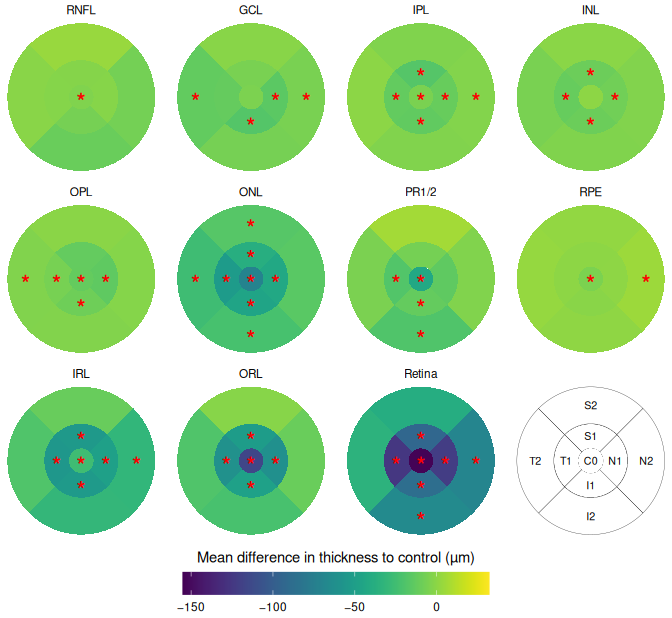

**Mean difference in thickness between STGD and controls by layer and segment.** Significant differences are denoted with a star (*).

# 5 Association between subfield thicknesses and visual function

|  | NON (N=47) | RP (N=29) | STGD (N=13) | CRD (N=14) |
| --- | --- | --- | --- | --- |
| logMAR |  |  |  |  |
| Mean (SD) | 0.186 (0.671) | 0.396 (0.290) | 1.52 (1.53) | 1.33 (1.45) |
| Median [Min, Max] | 0 [-0.223, 3.00] | 0.223 [0, 0.916] | 0.916 [0, 3.69] | 0.462 [0, 3.22] |
| age |  |  |  |  |
| Mean (SD) | 36.0 (16.2) | 36.9 (16.4) | 40.1 (16.7) | 33.2 (9.89) |
| Median [Min, Max] | 34.7 [8.86, 70.9] | 39.1 [7.40, 62.7] | 34.3 [14.1, 68.0] | 34.1 [18.2, 49.0] |
| sex |  |  |  |  |
| f | 23 (48.9%) | 16 (55.2%) | 9 (69.2%) | 6 (42.9%) |
| m | 24 (51.1%) | 13 (44.8%) | 4 (30.8%) | 8 (57.1%) |

```
##
##  Kruskal-Wallis rank sum test
##
## data:  vis_dat$logMAR and vis_dat$disease
## Kruskal-Wallis chi-squared = 30.19, df = 3, p-value = 1.259e-06
```

```
##                 z value   Pr(>|z|)
## RP - NON == 0     3.989 0.00019705 ***
## STGD - NON == 0   3.818 0.00039773 ***
## CRD - NON == 0    3.990 0.00019630 ***
```

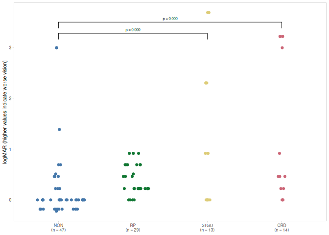

Top 20 segments most significantly associated with logMAR.

| layer | segment | Coefficient | SE | CI_low | CI_high | t | p | adj.p |
| --- | --- | --- | --- | --- | --- | --- | --- | --- |
| RPE | I1 | -0.063 | 0.010 | -0.083 | -0.043 | -6.157 | 0 | 0.000 |
| Retina | T1 | -0.004 | 0.001 | -0.005 | -0.003 | -6.002 | 0 | 0.000 |
| ONL | I1 | -0.009 | 0.001 | -0.012 | -0.006 | -5.792 | 0 | 0.000 |
| ONL | C0 | -0.007 | 0.001 | -0.009 | -0.005 | -5.741 | 0 | 0.000 |
| Retina | S2 | -0.006 | 0.001 | -0.008 | -0.004 | -5.639 | 0 | 0.000 |
| GCL | I2 | -0.038 | 0.007 | -0.051 | -0.024 | -5.414 | 0 | 0.000 |
| GCL | I1 | -0.026 | 0.005 | -0.036 | -0.016 | -5.300 | 0 | 0.000 |
| ORL | N1 | -0.005 | 0.001 | -0.007 | -0.003 | -5.252 | 0 | 0.000 |
| Retina | N1 | -0.004 | 0.001 | -0.005 | -0.002 | -5.149 | 0 | 0.000 |
| PR1_2 | C0 | -0.010 | 0.002 | -0.014 | -0.006 | -5.040 | 0 | 0.000 |
| ONL | N2 | -0.009 | 0.002 | -0.012 | -0.005 | -5.020 | 0 | 0.000 |
| Retina | I1 | -0.004 | 0.001 | -0.006 | -0.002 | -5.008 | 0 | 0.000 |
| ONL | T1 | -0.007 | 0.001 | -0.010 | -0.004 | -4.925 | 0 | 0.000 |
| ONL | S2 | -0.008 | 0.002 | -0.011 | -0.005 | -4.908 | 0 | 0.000 |
| RPE | C0 | -0.055 | 0.011 | -0.077 | -0.032 | -4.790 | 0 | 0.000 |
| Retina | T2 | -0.005 | 0.001 | -0.007 | -0.003 | -4.760 | 0 | 0.000 |
| ORL | T1 | -0.004 | 0.001 | -0.006 | -0.002 | -4.615 | 0 | 0.000 |
| Retina | N2 | -0.004 | 0.001 | -0.006 | -0.002 | -4.531 | 0 | 0.000 |
| PR1_2 | T1 | -0.010 | 0.002 | -0.014 | -0.005 | -4.521 | 0 | 0.000 |
| ONL | I2 | -0.009 | 0.002 | -0.013 | -0.005 | -4.497 | 0 | 0.001 |

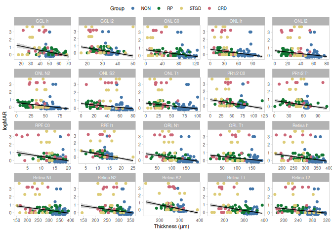

**Relationship between vision as logMAR and segment thicknesses within layers.** The regression line is obtained from a robust mixed model.

# 6 Licence

Copyright 2023 Julien Delarocque

Licensed under the Apache License, Version 2.0 (the “License”); you may not use this file except in compliance with the License. You may obtain a copy of the License at http://www.apache.org/licenses/LICENSE-2.0

Unless required by applicable law or agreed to in writing, software distributed under the License is distributed on an “AS IS” BASIS, WITHOUT WARRANTIES OR CONDITIONS OF ANY KIND, either express or implied. See the License for the specific language governing permissions and limitations under the License.

# 7 References

Delarocque, Julien. 2023. “Jkdel/Oct_analysis: Initial Release of an Example Analysis of OCT Data.” Zenodo. https://doi.org/10.5281/ZENODO.7590147.

Gersch, Julia, Katerina Hufendiek, Julien Delarocque, Carsten Framme, Christina Jacobsen, Heidi Stöhr, Ulrich Kellner, and Karsten Hufendiek. 2022. “Investigation of Structural Alterations in Inherited Retinal Diseases: A Quantitative SD-OCT-Analysis of Retinal Layer Thicknesses in Light of Underlying Genetic Mutations.” *International Journal of Molecular Sciences* 23 (24): 16007. https://doi.org/10.3390/ijms232416007.

# 8 Session information

**R version 4.2.2 (2022-10-31)**

**Platform:** x86_64-pc-linux-gnu (64-bit)

**locale:** *LC_CTYPE=fr_FR.UTF-8*, *LC_NUMERIC=C*, *LC_TIME=fr_FR.UTF-8*, *LC_COLLATE=fr_FR.UTF-8*, *LC_MONETARY=fr_FR.UTF-8*, *LC_MESSAGES=fr_FR.UTF-8*, *LC_PAPER=fr_FR.UTF-8*, *LC_NAME=C*, *LC_ADDRESS=C*, *LC_TELEPHONE=C*, *LC_MEASUREMENT=fr_FR.UTF-8* and *LC_IDENTIFICATION=C*

**attached base packages:** *stats*, *graphics*, *grDevices*, *utils*, *datasets*, *methods* and *base*

**other attached packages:** *patchwork(v.1.1.2)*, *ggpubr(v.0.5.0)*, *forcats(v.0.5.2)*, *stringr(v.1.5.0)*, *dplyr(v.1.0.10)*, *purrr(v.1.0.1)*, *readr(v.2.1.3)*, *tidyr(v.1.2.1)*, *tibble(v.3.1.8)*, *ggplot2(v.3.4.0)* and *tidyverse(v.1.3.2)*

**loaded via a namespace (and not attached):** *fs(v.1.6.0)*, *lubridate(v.1.9.0)*, *insight(v.0.18.8)*, *httr(v.1.4.4)*, *tools(v.4.2.2)*, *backports(v.1.4.1)*, *bslib(v.0.4.2)*, *utf8(v.1.2.2)*, *R6(v.2.5.1)*, *DBI(v.1.1.3)*, *colorspace(v.2.1-0)*, *withr(v.2.5.0)*, *tidyselect(v.1.2.0)*, *emmeans(v.1.8.4-1)*, *compiler(v.4.2.2)*, *cli(v.3.6.0)*, *rvest(v.1.0.3)*, *xml2(v.1.3.3)*, *sandwich(v.3.0-2)*, *bayestestR(v.0.13.0)*, *labeling(v.0.4.2)*, *sass(v.0.4.4)*, *scales(v.1.2.1)*, *mvtnorm(v.1.1-3)*, *signs(v.0.1.2.9000)*, *digest(v.0.6.31)*, *rmarkdown(v.2.20)*, *pkgconfig(v.2.0.3)*, *htmltools(v.0.5.4)*, *highr(v.0.10)*, *dbplyr(v.2.3.0)*, *fastmap(v.1.1.0)*, *ggthemes(v.4.2.4)*, *rlang(v.1.0.6)*, *readxl(v.1.4.1)*, *rstudioapi(v.0.14)*, *jquerylib(v.0.1.4)*, *farver(v.2.1.1)*, *generics(v.0.1.3)*, *zoo(v.1.8-11)*, *jsonlite(v.1.8.4)*, *car(v.3.1-1)*, *zip(v.2.2.2)*, *googlesheets4(v.1.0.1)*, *magrittr(v.2.0.3)*, *parameters(v.0.20.1)*, *Matrix(v.1.5-3)*, *Rcpp(v.1.0.10)*, *munsell(v.0.5.0)*, *fansi(v.1.0.4)*, *abind(v.1.4-5)*, *lifecycle(v.1.0.3)*, *stringi(v.1.7.12)*, *multcomp(v.1.4-20)*, *yaml(v.2.3.7)*, *carData(v.3.0-5)*, *MASS(v.7.3-58.2)*, *grid(v.4.2.2)*, *crayon(v.1.5.2)*, *lattice(v.0.20-45)*, *haven(v.2.5.1)*, *splines(v.4.2.2)*, *pander(v.0.6.5)*, *hms(v.1.1.2)*, *knitr(v.1.41)*, *pillar(v.1.8.1)*, *ggsignif(v.0.6.4)*, *estimability(v.1.4.1)*, *effectsize(v.0.8.2)*, *codetools(v.0.2-18)*, *reprex(v.2.0.2)*, *glue(v.1.6.2)*, *evaluate(v.0.20)*, *modelr(v.0.1.10)*, *vctrs(v.0.5.2)*, *tzdb(v.0.3.0)*, *tweenr(v.2.0.2)*, *cellranger(v.1.1.0)*, *gtable(v.0.3.1)*, *polyclip(v.1.10-4)*, *datawizard(v.0.6.5)*, *assertthat(v.0.2.1)*, *cachem(v.1.0.6)*, *xfun(v.0.36)*, *ggforce(v.0.4.1)*, *openxlsx(v.4.2.5.1)*, *xtable(v.1.8-4)*, *broom(v.1.0.2)*, *rstatix(v.0.7.1)*, *coda(v.0.19-4)*, *survival(v.3.5-0)*, *googledrive(v.2.0.0)*, *report(v.0.5.5)*, *gargle(v.1.2.1)*, *timechange(v.0.2.0)*, *TH.data(v.1.1-1)* and *ellipsis(v.0.3.2)*